# Reproducible Research Project Final

2024-02-20

# Analysis of Human and Economic Impact of Storms in United States

This report and the relevant data is available at https://github.com/mlnotes2718/RepResearchFinalProject

## SYNOPSIS

The following is an analysis of various kind of storm is the United States since 1950s. This analysis focus on human casualties and financial impact causes by various kind of storm. We need to answer the following questions:

1. Across the United States, which types of events are most harmful with respect to population health?
2. Across the United States, which types of events have the greatest economic consequences?

Based on the results, we concluded that the storm type that caused the most human casualties is **Tornado** and it is different from the storm type that has the most financial damage. The number one storm that caused the most financial damage is **Flood**. Hence policy maker should consider different type of response when addressing different type of storm.

## DATA PROCESSING

### Setting Environment

```r
# Import Library
library(dplyr)
library(stringr)
library(ggplot2)
library(reshape2)
library(kableExtra)
```

### Data Source and Documentation

Data Source: [U.S. National Oceanic and Atmospheric Administration (NOAA) - Storm Data](https://d396qusza40orc.cloudfront.net/repdata%2Fdata%2FStormData.csv.bz2)

URL: https://d396qusza40orc.cloudfront.net/repdata%2Fdata%2FStormData.csv.bz2

Documentation of Data Source: [National Weather Service Storm Data Documentation](https://d396qusza40orc.cloudfront.net/repdata%2Fpeer2_doc%2Fpd01016005curr.pdf)

[National Climatic Data Center Storm Events FAQ](https://d396qusza40orc.cloudfront.net/repdata%2Fpeer2_doc%2FNCDC%20Storm%20Events-FAQ%20Page.pdf)

### Download Data File

```r
fileURL <- "https://d396qusza40orc.cloudfront.net/repdata%2Fdata%2FStormData.csv.bz2"
if(!file.exists("./StormData.csv.bz2")) {
    download.file(fileURL, destfile = "./StormData.csv.bz2")
}
```

### Data Dictionary

[output not shown]

### Read File

```r
stormData <- read.csv("StormData.csv.bz2")
```

File Structure

```r
str(stormData)
```

```
## 'data.frame':    902297 obs. of  37 variables:
##  $ STATE__   : num  1 1 1 1 1 1 1 1 1 1 ...
##  $ BGN_DATE  : chr  "4/18/1950 0:00:00" "4/18/1950 0:00:00" "2/20/1951 0:00:00" "6/8/1951 0:00:00" ...
##  $ BGN_TIME  : chr  "0130" "0145" "1600" "0900" ...
##  $ TIME_ZONE : chr  "CST" "CST" "CST" "CST" ...
##  $ COUNTY    : num  97 3 57 89 43 77 9 123 125 57 ...
##  $ COUNTYNAME: chr  "MOBILE" "BALDWIN" "FAYETTE" "MADISON" ...
##  $ STATE     : chr  "AL" "AL" "AL" "AL" ...
##  $ EVTYPE    : chr  "TORNADO" "TORNADO" "TORNADO" "TORNADO" ...
##  $ BGN_RANGE : num  0 0 0 0 0 0 0 0 0 0 ...
##  $ BGN_AZI   : chr  "" "" "" "" ...
##  $ BGN_LOCATI: chr  "" "" "" "" ...
##  $ END_DATE  : chr  "" "" "" "" ...
##  $ END_TIME  : chr  "" "" "" "" ...
##  $ COUNTY_END: num  0 0 0 0 0 0 0 0 0 0 ...
```

[output cut: 23 more lines]

**Data contains 902297 with 37 columns.**

### Processing Data

1. First we will filter out those data that has fatalities, injuries, property damage and crop damage.

```r
reducedStormData <- filter(stormData, FATALITIES != 0 | INJURIES !=0 |PROPDMG !=0 | CROPDMG != 0)
```

2. We select relevant column for our analysis. We do not need all the 37 columns from the raw data.

```r
reducedStormData <- select(reducedStormData, STATE, BGN_DATE, EVTYPE, FATALITIES,INJURIES,PROPDMG,PROPDMGEXP,CROPDMG,CROPDMGEXP,REMARKS)
```

Check for NA

```r
stormTypeNA <- is.na(reducedStormData$EVTYPE)
filter(reducedStormData, stormTypeNA)
```

```
##  [1] STATE      BGN_DATE   EVTYPE     FATALITIES INJURIES   PROPDMG
##  [7] PROPDMGEXP CROPDMG    CROPDMGEXP REMARKS
## <0 rows> (or 0-length row.names)
```

No NA for storm type

```r
casualtiesNA <- is.na(reducedStormData$FATALITIES | reducedStormData$INJURIES)
filter(reducedStormData, casualtiesNA)
```

```
##  [1] STATE      BGN_DATE   EVTYPE     FATALITIES INJURIES   PROPDMG
##  [7] PROPDMGEXP CROPDMG    CROPDMGEXP REMARKS
## <0 rows> (or 0-length row.names)
```

No NA for fatalities or injuries.

```r
damageNA <- is.na(reducedStormData$PROPDMG | reducedStormData$CROPDMG)
filter(reducedStormData, damageNA)
```

```
##  [1] STATE      BGN_DATE   EVTYPE     FATALITIES INJURIES   PROPDMG
##  [7] PROPDMGEXP CROPDMG    CROPDMGEXP REMARKS
## <0 rows> (or 0-length row.names)
```

No NA for property or crop damage.

3. File Structure after file size reduction.

```r
str(reducedStormData)
```

```
## 'data.frame':    254633 obs. of  10 variables:
##  $ STATE     : chr  "AL" "AL" "AL" "AL" ...
##  $ BGN_DATE  : chr  "4/18/1950 0:00:00" "4/18/1950 0:00:00" "2/20/1951 0:00:00" "6/8/1951 0:00:00" ...
##  $ EVTYPE    : chr  "TORNADO" "TORNADO" "TORNADO" "TORNADO" ...
##  $ FATALITIES: num  0 0 0 0 0 0 0 0 1 0 ...
##  $ INJURIES  : num  15 0 2 2 2 6 1 0 14 0 ...
##  $ PROPDMG   : num  25 2.5 25 2.5 2.5 2.5 2.5 2.5 25 25 ...
##  $ PROPDMGEXP: chr  "K" "K" "K" "K" ...
##  $ CROPDMG   : num  0 0 0 0 0 0 0 0 0 0 ...
##  $ CROPDMGEXP: chr  "" "" "" "" ...
##  $ REMARKS   : chr  "" "" "" "" ...
```

**We have 254633 rows with 10 columns.**

#### Examine Storm Event Classification

```r
unique(reducedStormData$EVTYPE)
```

```
##   [1] "TORNADO"                        "TSTM WIND"
##   [3] "HAIL"                           "ICE STORM/FLASH FLOOD"
##   [5] "WINTER STORM"                   "HURRICANE OPAL/HIGH WINDS"
##   [7] "THUNDERSTORM WINDS"             "HURRICANE ERIN"
##   [9] "HURRICANE OPAL"                 "HEAVY RAIN"
##  [11] "LIGHTNING"                      "THUNDERSTORM WIND"
##  [13] "DENSE FOG"                      "RIP CURRENT"
##  [15] "THUNDERSTORM WINS"              "FLASH FLOODING"
##  [17] "FLASH FLOOD"                    "TORNADO F0"
##  [19] "THUNDERSTORM WINDS LIGHTNING"   "THUNDERSTORM WINDS/HAIL"
##  [21] "HEAT"                           "HIGH WINDS"
##  [23] "WIND"                           "HEAVY RAINS"
##  [25] "LIGHTNING AND HEAVY RAIN"       "THUNDERSTORM WINDS HAIL"
##  [27] "COLD"                           "HEAVY RAIN/LIGHTNING"
##  [29] "FLASH FLOODING/THUNDERSTORM WI" "FLOODING"
```

[output cut: 229 more lines]

- There are 488 different type of storm classification. This does not match with the official 48 classification.
- There are leading and tailing space in the storm type.
- Some classification contains 2 space.
- There is also a mixed of upper and lower case.

We need to clean up EVTYPE. Besides remove leading, trailing and double space, we also need to convert all storm type to upper case.

We also check the Property and Crop Damage Exponent

```r
unique(reducedStormData$PROPDMGEXP)
```

```
##  [1] "K" "M" ""  "B" "m" "+" "0" "5" "6" "4" "h" "2" "7" "3" "H" "-"
```

```r
unique(reducedStormData$CROPDMGEXP)
```

```
## [1] ""  "M" "K" "m" "B" "?" "0" "k"
```

There is also mixed lower and upper case which we can fixed together. The following code is to clean up trailing and leading space and upper and lower case for EVTYPE, PROPDMGEXP and CROPDMGEXP

```r
reducedStormData$EVTYPE <- trimws(reducedStormData$EVTYPE, which = c("both"), whitespace = "[ \t\r\n]")
reducedStormData$EVTYPE <- tolower(reducedStormData$EVTYPE)
reducedStormData$EVTYPE <- toupper(reducedStormData$EVTYPE)
reducedStormData$EVTYPE <- str_squish(reducedStormData$EVTYPE)

reducedStormData$PROPDMGEXP <- toupper(reducedStormData$PROPDMGEXP)
reducedStormData$CROPDMGEXP <- toupper(reducedStormData$CROPDMGEXP)
```

We also sort storm type:

```r
evtypeLst <- sort(unique(reducedStormData$EVTYPE))
evtypeLst
```

```
##   [1] "?"                              "AGRICULTURAL FREEZE"
##   [3] "APACHE COUNTY"                  "ASTRONOMICAL HIGH TIDE"
##   [5] "ASTRONOMICAL LOW TIDE"          "AVALANCE"
##   [7] "AVALANCHE"                      "BEACH EROSION"
##   [9] "BLACK ICE"                      "BLIZZARD"
##  [11] "BLIZZARD/WINTER STORM"          "BLOWING DUST"
##  [13] "BLOWING SNOW"                   "BREAKUP FLOODING"
##  [15] "BRUSH FIRE"                     "COASTAL EROSION"
##  [17] "COASTAL FLOOD"                  "COASTAL FLOODING"
##  [19] "COASTAL FLOODING/EROSION"       "COASTAL STORM"
##  [21] "COASTAL SURGE"                  "COASTALSTORM"
##  [23] "COLD"                           "COLD AIR TORNADO"
##  [25] "COLD AND SNOW"                  "COLD AND WET CONDITIONS"
##  [27] "COLD TEMPERATURE"               "COLD WAVE"
##  [29] "COLD WEATHER"                   "COLD/WIND CHILL"
```

[output cut: 205 more lines]

**Misclassification reduce to 440**.

### Fixing Misclassification

The most ideal way to handle misclassification is to read the remarks for each event that are misclassified. However, due to constrain of resource, we adopt the strategy of reclassify those obvious spelling error by hand. We will not reclassify all misclassification. We are good as long as the unique classification is less than 100.

However, we did examine the remarks of 2 obvious misclassification. They are “?” and “APACHE COUNTY”

The following code is our clean up code.

For further details please refer to Appendix A in separate document.

```r
# Start Obvious Classification
reducedStormData$EVTYPE[grepl("ASTRONOMICAL HIGH TIDE", reducedStormData$EVTYPE)] <- "ASTRONOMICAL LOW TIDE"
reducedStormData$EVTYPE[grepl("AVALANCE", reducedStormData$EVTYPE)] <- "AVALANCHE"


# Blizzard
reducedStormData$EVTYPE[grepl("BLIZZARD/WINTER STORM", reducedStormData$EVTYPE)] <- "BLIZZARD"
reducedStormData$EVTYPE[grepl("GROUND BLIZZARD", reducedStormData$EVTYPE)] <- "BLIZZARD"


# Coastal Flood
reducedStormData$EVTYPE[grepl("^COASTAL*", reducedStormData$EVTYPE)] <- "COASTAL FLOOD"
reducedStormData$EVTYPE[grepl("EROSION/CSTL FLOOD", reducedStormData$EVTYPE)] <- "COASTAL FLOOD"


# COLD/WIND CHILL
reducedStormData$EVTYPE[grepl("^COLD*", reducedStormData$EVTYPE)] <- "COLD/WIND CHILL"
reducedStormData$EVTYPE[grepl("UNSEASONABLE COLD", reducedStormData$EVTYPE)] <- "COLD/WIND CHILL"
reducedStormData$EVTYPE[grepl("UNSEASONABLY COLD", reducedStormData$EVTYPE)] <- "COLD/WIND CHILL"
reducedStormData$EVTYPE[grepl("COOL AND WET", reducedStormData$EVTYPE)] <- "COLD/WIND CHILL"


# Dust Devil/Strom
reducedStormData$EVTYPE[grepl("^DUST DEVIL*", reducedStormData$EVTYPE)] <- "DUST DEVIL"
reducedStormData$EVTYPE[grepl("^DUST STORM*", reducedStormData$EVTYPE)] <- "DUST STORM"
reducedStormData$EVTYPE[grepl("^DRY MICROBURST*", reducedStormData$EVTYPE)] <- "DUST STORM"
reducedStormData$EVTYPE[grepl("BLOWING DUST", reducedStormData$EVTYPE)] <- "DUST STORM"


# Excessive Heat
reducedStormData$EVTYPE[grepl("^EXTREME HEAT*", reducedStormData$EVTYPE)] <- "EXCESSIVE HEAT"
reducedStormData$EVTYPE[grepl("^RECORD HEAT*", reducedStormData$EVTYPE)] <- "EXCESSIVE HEAT"
reducedStormData$EVTYPE[grepl("RECORD/EXCESSIVE HEAT", reducedStormData$EVTYPE)] <- "EXCESSIVE HEAT"


# Extreme Cold/Wind Chill
reducedStormData$EVTYPE[grepl("^EXTREME COLD*", reducedStormData$EVTYPE)] <- "EXTREME COLD/WIND CHILL"
reducedStormData$EVTYPE[grepl("^EXTREME WIND*", reducedStormData$EVTYPE)] <- "EXTREME COLD/WIND CHILL"
reducedStormData$EVTYPE[grepl("^EXTENDED*", reducedStormData$EVTYPE)] <- "EXTREME COLD/WIND CHILL"
reducedStormData$EVTYPE[grepl("EXCESSIVE WETNESS", reducedStormData$EVTYPE)] <- "EXTREME COLD/WIND CHILL"
reducedStormData$EVTYPE[grepl("RECORD COLD", reducedStormData$EVTYPE)] <- "EXTREME COLD/WIND CHILL"

# Flash Flood
reducedStormData$EVTYPE[grepl("^FLASH FLOOD*", reducedStormData$EVTYPE)] <- "FLASH FLOOD"

# Other Flood
reducedStormData$EVTYPE[grepl("^FLOOD*", reducedStormData$EVTYPE)] <- "FLOOD"
reducedStormData$EVTYPE[grepl("^URBAN*", reducedStormData$EVTYPE)] <- "FLOOD"
reducedStormData$EVTYPE[grepl("^RIVER.*FLOOD", reducedStormData$EVTYPE)] <- "FLOOD"

reducedStormData$EVTYPE[grepl("^MINOR FLOODING", reducedStormData$EVTYPE)] <- "FLOOD"
reducedStormData$EVTYPE[grepl("MAJOR FLOOD", reducedStormData$EVTYPE)] <- "FLOOD"
reducedStormData$EVTYPE[grepl("BREAKUP FLOODING", reducedStormData$EVTYPE)] <- "FLOOD"
reducedStormData$EVTYPE[grepl("SMALL STREAM FLOOD", reducedStormData$EVTYPE)] <- "FLOOD"
reducedStormData$EVTYPE[grepl("RURAL FLOOD", reducedStormData$EVTYPE)] <- "FLOOD"

# Freezing Fog
reducedStormData$EVTYPE[grepl("FOG", reducedStormData$EVTYPE)] <- "FREEZING FOG"

# Frost/Freeze
reducedStormData$EVTYPE[grepl("FROST\\FREEZE", reducedStormData$EVTYPE)] <- "FROST/FREEZE"
reducedStormData$EVTYPE[grepl("FROST", reducedStormData$EVTYPE)] <- "FROST/FREEZE"
reducedStormData$EVTYPE[grepl("FREEZE", reducedStormData$EVTYPE)] <- "FROST/FREEZE"

reducedStormData$EVTYPE[grepl("FREEZING RAIN", reducedStormData$EVTYPE)] <- "FROST/FREEZE"
reducedStormData$EVTYPE[grepl("FREEZING DRIZZLE", reducedStormData$EVTYPE)] <- "FROST/FREEZE"
reducedStormData$EVTYPE[grepl("FREEZING SPRAY", reducedStormData$EVTYPE)] <- "FROST/FREEZE"
reducedStormData$EVTYPE[grepl("^HYPOTHERMIA.*", reducedStormData$EVTYPE)] <- "FROST/FREEZE"
reducedStormData$EVTYPE[grepl("HYPERTHERMIA/EXPOSURE", reducedStormData$EVTYPE)] <- "FROST/FREEZE"


# Hail
reducedStormData$EVTYPE[grepl("^HAIL*", reducedStormData$EVTYPE)] <- "HAIL"


# Heat
reducedStormData$EVTYPE[grepl("^HEAT *", reducedStormData$EVTYPE)] <- "HEAT"


# Heavy Rain
reducedStormData$EVTYPE[grepl("^RAIN*", reducedStormData$EVTYPE)] <- "HEAVY RAIN"
reducedStormData$EVTYPE[grepl("^HEAVY RAIN*", reducedStormData$EVTYPE)] <- "HEAVY RAIN"
reducedStormData$EVTYPE[grepl("HEAVY PRECIPITATION", reducedStormData$EVTYPE)] <- "HEAVY RAIN"
reducedStormData$EVTYPE[grepl("HEAVY SHOWER", reducedStormData$EVTYPE)] <- "HEAVY RAIN"
reducedStormData$EVTYPE[grepl("EXCESSIVE RAINFALL", reducedStormData$EVTYPE)] <- "HEAVY RAIN"
reducedStormData$EVTYPE[grepl("RECORD RAINFALL", reducedStormData$EVTYPE)] <- "HEAVY RAIN"
reducedStormData$EVTYPE[grepl("UNSEASONAL RAIN", reducedStormData$EVTYPE)] <- "HEAVY RAIN"
reducedStormData$EVTYPE[grepl("HVY RAIN", reducedStormData$EVTYPE)] <- "HEAVY RAIN"


# Heavy Snow
reducedStormData$EVTYPE[grepl("^HEAVY SNOW*", reducedStormData$EVTYPE)] <- "HEAVY SNOW"
reducedStormData$EVTYPE[grepl("BLOWING SNOW", reducedStormData$EVTYPE)] <- "HEAVY SNOW"
reducedStormData$EVTYPE[grepl("FALLING SNOW/ICE", reducedStormData$EVTYPE)] <- "HEAVY SNOW"
reducedStormData$EVTYPE[grepl("LATE SEASON SNOW", reducedStormData$EVTYPE)] <- "HEAVY SNOW"
reducedStormData$EVTYPE[grepl("EXCESSIVE SNOW", reducedStormData$EVTYPE)] <- "HEAVY SNOW"
reducedStormData$EVTYPE[grepl("HEAVY LAKE SNOW", reducedStormData$EVTYPE)] <- "HEAVY SNOW"
reducedStormData$EVTYPE[grepl("RECORD SNOW", reducedStormData$EVTYPE)] <- "HEAVY SNOW"


# High Surf
reducedStormData$EVTYPE[grepl("^HEAVY SURF*", reducedStormData$EVTYPE)] <- "HIGH SURF"
reducedStormData$EVTYPE[grepl("HAZARDOUS SURF", reducedStormData$EVTYPE)] <- "HIGH SURF"
reducedStormData$EVTYPE[grepl("HIGH SURF ADVISORY", reducedStormData$EVTYPE)] <- "HIGH SURF"
reducedStormData$EVTYPE[grepl("HIGH SWELLS", reducedStormData$EVTYPE)] <- "HIGH SURF"
reducedStormData$EVTYPE[grepl("HIGH WAVES", reducedStormData$EVTYPE)] <- "HIGH SURF"


# High Wind
reducedStormData$EVTYPE[grepl("^HIGH WIND*", reducedStormData$EVTYPE)] <- "HIGH WIND"


# Hurricane (Typhoon)
reducedStormData$EVTYPE[grepl("^HURRICANE*", reducedStormData$EVTYPE)] <- "HURRICANE (TYPHOON)"
reducedStormData$EVTYPE[grepl("^TYPHOON", reducedStormData$EVTYPE)] <- "HURRICANE (TYPHOON)"


# Ice Storm
reducedStormData$EVTYPE[grepl("^ICE*", reducedStormData$EVTYPE)] <- "ICE STORM"
reducedStormData$EVTYPE[grepl("BLACK ICE", reducedStormData$EVTYPE)] <- "ICE STORM"
reducedStormData$EVTYPE[grepl("^GLAZE", reducedStormData$EVTYPE)] <- "ICE STORM"


# Lakeshore Flood
reducedStormData$EVTYPE[grepl("^LAKE FLOOD", reducedStormData$EVTYPE)] <- "LAKESHORE FLOOD"


# Lake-Effect Snow
reducedStormData$EVTYPE[grepl("^LAKE EFFECT SNOW", reducedStormData$EVTYPE)] <- "LAKE-EFFECT SNOW"


# Lightning
reducedStormData$EVTYPE[grepl("^LIGHT*", reducedStormData$EVTYPE)] <- "LIGHTNING"
reducedStormData$EVTYPE[grepl("^LIGNTNING", reducedStormData$EVTYPE)] <- "LIGHTNING"


# Marine Thunderstorm Wind
reducedStormData$EVTYPE[grepl("^MARINE TSTM WIND", reducedStormData$EVTYPE)] <- "MARINE THUNDERSTORM WIND"


# Rip Current
reducedStormData$EVTYPE[grepl("^RIP CURRENT.*", reducedStormData$EVTYPE)] <- "RIP CURRENT"


# Strong Wind
reducedStormData$EVTYPE[grepl("^GUST*", reducedStormData$EVTYPE)] <- "STRONG WIND"
reducedStormData$EVTYPE[grepl("^STRONG WIND*", reducedStormData$EVTYPE)] <- "STRONG WIND"
reducedStormData$EVTYPE[grepl("^WIND", reducedStormData$EVTYPE)] <- "STRONG WIND"


# Thunderstorm Wind
reducedStormData$EVTYPE[grepl("^TSTM*", reducedStormData$EVTYPE)] <- "THUNDERSTORM WIND"
reducedStormData$EVTYPE[grepl("^THU*", reducedStormData$EVTYPE)] <- "THUNDERSTORM WIND"
reducedStormData$EVTYPE[grepl("^TUNDERSTORM*", reducedStormData$EVTYPE)] <- "THUNDERSTORM WIND"
reducedStormData$EVTYPE[grepl("^SEVERE*", reducedStormData$EVTYPE)] <- "THUNDERSTORM WIND"


# Tornado
reducedStormData$EVTYPE[grepl("^TORNADO*", reducedStormData$EVTYPE)] <- "TORNADO"
reducedStormData$EVTYPE[grepl("^TORNDAO*", reducedStormData$EVTYPE)] <- "TORNADO"


# Tropical Storm
reducedStormData$EVTYPE[grepl("^TROPICAL STORM*", reducedStormData$EVTYPE)] <- "TROPICAL STORM"


# Waterspout
reducedStormData$EVTYPE[grepl("^WATERSPOUT*", reducedStormData$EVTYPE)] <- "WATERSPOUT"


# Winter Storm
reducedStormData$EVTYPE[grepl("^WINTER STORM*", reducedStormData$EVTYPE)] <- "WINTER STORM"


# Winter Weather
reducedStormData$EVTYPE[grepl("^WINTER WEATHER*", reducedStormData$EVTYPE)] <- "WINTER WEATHER"
reducedStormData$EVTYPE[grepl("WINTRY MIX", reducedStormData$EVTYPE)] <- "WINTER WEATHER"
reducedStormData$EVTYPE[grepl("^SNOW.*", reducedStormData$EVTYPE)] <- "WINTER WEATHER"



# Wildfire
reducedStormData$EVTYPE[grepl("^WILD.*FIRE*", reducedStormData$EVTYPE)] <- "WILDFIRE"
reducedStormData$EVTYPE[grepl("^BRUSH FIRE", reducedStormData$EVTYPE)] <- "WILDFIRE"
reducedStormData$EVTYPE[grepl("^FOREST FIRE*", reducedStormData$EVTYPE)] <- "WILDFIRE"
reducedStormData$EVTYPE[grepl("^GRASS FIRE*", reducedStormData$EVTYPE)] <- "WILDFIRE"


# Re-classify APACHE COUNTY
reducedStormData$EVTYPE[grepl("APACHE COUNTY", reducedStormData$EVTYPE)] <- "THUNDERSTORM WIND"
```

### Remove Unwanted Rows

```r
removeEvtypeCondition <- c("?")
cleanStormData <- subset(reducedStormData, EVTYPE != removeEvtypeCondition)
```

File Structure of Clean Data

```r
str(cleanStormData)
```

```
## 'data.frame':    254632 obs. of  10 variables:
##  $ STATE     : chr  "AL" "AL" "AL" "AL" ...
##  $ BGN_DATE  : chr  "4/18/1950 0:00:00" "4/18/1950 0:00:00" "2/20/1951 0:00:00" "6/8/1951 0:00:00" ...
##  $ EVTYPE    : chr  "TORNADO" "TORNADO" "TORNADO" "TORNADO" ...
##  $ FATALITIES: num  0 0 0 0 0 0 0 0 1 0 ...
##  $ INJURIES  : num  15 0 2 2 2 6 1 0 14 0 ...
##  $ PROPDMG   : num  25 2.5 25 2.5 2.5 2.5 2.5 2.5 25 25 ...
##  $ PROPDMGEXP: chr  "K" "K" "K" "K" ...
##  $ CROPDMG   : num  0 0 0 0 0 0 0 0 0 0 ...
##  $ CROPDMGEXP: chr  "" "" "" "" ...
##  $ REMARKS   : chr  "" "" "" "" ...
```

**We have a total of 254632 rows and 10 columns.**

### Convert PROPDMGEXP and CROPDMGEXP

We also need to convert the exponent of the property and crop damage. The exponent of k or K represent thousands. M or m in millions. Any number is equivalent to 10 to the power of the number. (e.g. 7 = 10^7)

First we need to find out the unique exponent of PROPDMGEXP and CROPDMGEXP.

```r
uniquePROPDMGEXP <- unique(cleanStormData$PROPDMGEXP)
uniqueCROPDMGEXP <- unique(cleanStormData$CROPDMGEXP)
uniqueBothDMGEXP <- union(uniquePROPDMGEXP, uniqueCROPDMGEXP)
uniqueBothDMGEXP <- sort(uniqueBothDMGEXP)
uniqueBothDMGEXP
```

```
##  [1] ""  "-" "?" "+" "0" "2" "3" "4" "5" "6" "7" "B" "H" "K" "M"
```

The empty string “” will caused a problem, so we will replace those empty string with ‘-’ on the clean dataset.

```r
cleanStormData$PROPDMGEXP[cleanStormData$PROPDMGEXP == ""] <- '-'
cleanStormData$CROPDMGEXP[cleanStormData$CROPDMGEXP == ""] <- '-'
```

Next, we regenerate the unique values again

```r
uniquePROPDMGEXP <- unique(cleanStormData$PROPDMGEXP)
uniqueCROPDMGEXP <- unique(cleanStormData$CROPDMGEXP)
uniqueBothDMGEXP <- union(uniquePROPDMGEXP, uniqueCROPDMGEXP)
uniqueBothDMGEXP <- sort(uniqueBothDMGEXP)
uniqueBothDMGEXP
```

```
##  [1] "-" "?" "+" "0" "2" "3" "4" "5" "6" "7" "B" "H" "K" "M"
```

The corresponding replacement values will be as follows:

| Exponent | Values |
| --- | --- |
| - | 0 |
| ? | 0 |
| + | 1 |
| 0 | 10^0 |
| 2 | 10^2 |
| 3 | 10^3 |
| 4 | 10^4 |
| 5 | 10^5 |
| 6 | 10^6 |
| 7 | 10^7 |
| B | 1000000000 |
| H | 100 |
| K | 1000 |
| M | 1000000 |

For details, we can refers to external document:

https://rstudio-pubs-static.s3.amazonaws.com/58957_37b6723ee52b455990e149edde45e5b6.html

```r
replacement <- c(0,0,1,10^0,10^2,10^3,10^4,10^5,10^6,10^7,1000000000,100,1000,1000000)
names(replacement) <- uniqueBothDMGEXP
replacement
```

```
##     -     ?     +     0     2     3     4     5     6     7     B     H     K
## 0e+00 0e+00 1e+00 1e+00 1e+02 1e+03 1e+04 1e+05 1e+06 1e+07 1e+09 1e+02 1e+03
##     M
## 1e+06
```

Instead of replacing the current PROPDMGEXP, we create a new column called PROPDMGEXPNUM which store the numeric values based on the reference above. We also perform similar action for CROPDMGEXPNUM. The reason for creating additional column instead of replacing the existing exponent so that we can refer to the original exponent. We can also check for errors when in doubt.

```r
cleanStormData <- cleanStormData %>%
  mutate(PROPDMGEXPNUM = replacement[cleanStormData$PROPDMGEXP]) %>%
  mutate(CROPDMGEXPNUM = replacement[cleanStormData$CROPDMGEXP])
```

At this stage, we data cleanup is completed under the new data frame **cleanStormData**. At the next stage, we will be adding analytics information for analysis.

## DATA ANLYTICS

### Addition of Analytics Data

At this stage, we will add new column PROPDMGSUM and CROPDMGSUM. These 2 column will calculate the fill property damage and crop damage. The computation is PROPDMG multiple by PROPDMGEXPNUM.

```r
cleanStormData <- cleanStormData %>%
  mutate(PROPDMGSUM = PROPDMG * PROPDMGEXPNUM) %>%
  mutate(CROPDMGSUM = CROPDMG * CROPDMGEXPNUM)
```

We use select function to re-order the columns

```r
cleanStormData <- select(cleanStormData, STATE, BGN_DATE, EVTYPE, FATALITIES, INJURIES, PROPDMG, PROPDMGEXP, PROPDMGEXPNUM, PROPDMGSUM, CROPDMG, CROPDMGEXP,CROPDMGSUM, REMARKS)
head(cleanStormData)
```

```
##   STATE           BGN_DATE  EVTYPE FATALITIES INJURIES PROPDMG PROPDMGEXP
## 1    AL  4/18/1950 0:00:00 TORNADO          0       15    25.0          K
## 2    AL  4/18/1950 0:00:00 TORNADO          0        0     2.5          K
## 3    AL  2/20/1951 0:00:00 TORNADO          0        2    25.0          K
## 4    AL   6/8/1951 0:00:00 TORNADO          0        2     2.5          K
## 5    AL 11/15/1951 0:00:00 TORNADO          0        2     2.5          K
## 6    AL 11/15/1951 0:00:00 TORNADO          0        6     2.5          K
##   PROPDMGEXPNUM PROPDMGSUM CROPDMG CROPDMGEXP CROPDMGSUM REMARKS
## 1          1000      25000       0          -          0
## 2          1000       2500       0          -          0
## 3          1000      25000       0          -          0
## 4          1000       2500       0          -          0
## 5          1000       2500       0          -          0
## 6          1000       2500       0          -          0
```

### Create Data Frame to Answer Question

Finally, we will create separate dataframe to answer our question of which storm type has the most casualties and economic damage.

#### Analysis Storm Type with Casualties

Next, We then create a data frame **fatalDf** that is group by the event type and filter out data with fatalities or injuries.

```r
fatalDf <- cleanStormData %>%
    group_by(EVTYPE) %>%
    filter(FATALITIES != 0 | INJURIES != 0) %>%
    summarise(FATALITIES_TOTAL=sum(FATALITIES), INJURIES_TOTAL=sum(INJURIES)) %>%
    arrange(desc(FATALITIES_TOTAL))
```

We select the top 10 event that has the worst fatalities and/or injuries

```r
rankedCasualties <- fatalDf[1:10,]
rankedCasualties
```

```
## # A tibble: 10 × 3
##    EVTYPE                  FATALITIES_TOTAL INJURIES_TOTAL
##    <chr>                              <dbl>          <dbl>
##  1 TORNADO                             5658          91364
##  2 EXCESSIVE HEAT                      2018           6730
##  3 HEAT                                1118           2494
##  4 FLASH FLOOD                         1018           1785
##  5 LIGHTNING                            818           5234
##  6 THUNDERSTORM WIND                    712           9509
##  7 RIP CURRENT                          577            529
##  8 FLOOD                                529           6888
##  9 EXTREME COLD/WIND CHILL              306            260
## 10 HIGH WIND                            293           1471
```

We need to convert and melt the dataframe into a format for plotting

```r
plotDataCasualties <- as.data.frame(rankedCasualties)
meltedPlotDataCasualties <- melt(plotDataCasualties, id.vars="EVTYPE", variable.name = "Casualties")
meltedPlotDataCasualties
```

```
##                     EVTYPE       Casualties value
## 1                  TORNADO FATALITIES_TOTAL  5658
## 2           EXCESSIVE HEAT FATALITIES_TOTAL  2018
## 3                     HEAT FATALITIES_TOTAL  1118
## 4              FLASH FLOOD FATALITIES_TOTAL  1018
## 5                LIGHTNING FATALITIES_TOTAL   818
## 6        THUNDERSTORM WIND FATALITIES_TOTAL   712
## 7              RIP CURRENT FATALITIES_TOTAL   577
## 8                    FLOOD FATALITIES_TOTAL   529
## 9  EXTREME COLD/WIND CHILL FATALITIES_TOTAL   306
## 10               HIGH WIND FATALITIES_TOTAL   293
## 11                 TORNADO   INJURIES_TOTAL 91364
## 12          EXCESSIVE HEAT   INJURIES_TOTAL  6730
## 13                    HEAT   INJURIES_TOTAL  2494
## 14             FLASH FLOOD   INJURIES_TOTAL  1785
## 15               LIGHTNING   INJURIES_TOTAL  5234
## 16       THUNDERSTORM WIND   INJURIES_TOTAL  9509
## 17             RIP CURRENT   INJURIES_TOTAL   529
## 18                   FLOOD   INJURIES_TOTAL  6888
## 19 EXTREME COLD/WIND CHILL   INJURIES_TOTAL   260
## 20               HIGH WIND   INJURIES_TOTAL  1471
```

#### Analysis Storm Type with Economic Damage

To answer the question for storm type with most economic damage, we then create a data frame **econDf** that is group by the event type and filter out data with property or crop damage. We sort using property damage.

```r
econDf <- cleanStormData %>%
    group_by(EVTYPE) %>%
    filter(PROPDMGSUM != 0 | CROPDMGSUM != 0) %>%
    summarise(PROPDMG_TOTAL=sum(PROPDMGSUM), CROPDMG_TOTAL=sum(CROPDMGSUM)) %>%
    arrange(desc(PROPDMG_TOTAL))
```

Next, we check the top 10 storm with largest property damage.

```r
econDf[1:10,]
```

```
## # A tibble: 10 × 3
##    EVTYPE              PROPDMG_TOTAL CROPDMG_TOTAL
##    <chr>                       <dbl>         <dbl>
##  1 FLOOD               150381848379    10945975050
##  2 HURRICANE (TYPHOON)  85356410010     5516117800
##  3 TORNADO              58552152374.     417461470
##  4 STORM SURGE          43323536000           5000
##  5 FLASH FLOOD          17414730872.    1437163150
##  6 HAIL                 15977469956.    3026094620
##  7 THUNDERSTORM WIND    11179194073.    1271663980
##  8 WILDFIRE              8496628500      403281630
##  9 TROPICAL STORM        7714390550      694896000
## 10 WINTER STORM          6748997251       32444000
```

The property and crop damage seems very large. For ease of reading, we convert the financial values into billions:

```r
rankedEconomicImpact <- econDf[1:10,]
rankedEconomicImpact$PROPDMG_TOTAL <- rankedEconomicImpact$PROPDMG_TOTAL/1000000000
rankedEconomicImpact$CROPDMG_TOTAL <- rankedEconomicImpact$CROPDMG_TOTAL/1000000000
rankedEconomicImpact <- rankedEconomicImpact %>%
  rename(Property_Damage=PROPDMG_TOTAL, Crop_Damage = CROPDMG_TOTAL)
rankedEconomicImpact
```

```
## # A tibble: 10 × 3
##    EVTYPE              Property_Damage Crop_Damage
##    <chr>                         <dbl>       <dbl>
##  1 FLOOD                        150.     10.9
##  2 HURRICANE (TYPHOON)           85.4     5.52
##  3 TORNADO                       58.6     0.417
##  4 STORM SURGE                   43.3     0.000005
##  5 FLASH FLOOD                   17.4     1.44
##  6 HAIL                          16.0     3.03
##  7 THUNDERSTORM WIND             11.2     1.27
##  8 WILDFIRE                       8.50    0.403
##  9 TROPICAL STORM                 7.71    0.695
## 10 WINTER STORM                   6.75    0.0324
```

```r
plotDataEcon <- as.data.frame(rankedEconomicImpact)
meltedPlotDataEcon <- melt(plotDataEcon, id.vars="EVTYPE", variable.name = "Damages")
meltedPlotDataEcon
```

```
##                 EVTYPE         Damages       value
## 1                FLOOD Property_Damage 150.3818484
## 2  HURRICANE (TYPHOON) Property_Damage  85.3564100
## 3              TORNADO Property_Damage  58.5521524
## 4          STORM SURGE Property_Damage  43.3235360
## 5          FLASH FLOOD Property_Damage  17.4147309
## 6                 HAIL Property_Damage  15.9774700
## 7    THUNDERSTORM WIND Property_Damage  11.1791941
## 8             WILDFIRE Property_Damage   8.4966285
## 9       TROPICAL STORM Property_Damage   7.7143906
## 10        WINTER STORM Property_Damage   6.7489973
## 11               FLOOD     Crop_Damage  10.9459750
## 12 HURRICANE (TYPHOON)     Crop_Damage   5.5161178
## 13             TORNADO     Crop_Damage   0.4174615
## 14         STORM SURGE     Crop_Damage   0.0000050
## 15         FLASH FLOOD     Crop_Damage   1.4371631
## 16                HAIL     Crop_Damage   3.0260946
## 17   THUNDERSTORM WIND     Crop_Damage   1.2716640
## 18            WILDFIRE     Crop_Damage   0.4032816
## 19      TROPICAL STORM     Crop_Damage   0.6948960
## 20        WINTER STORM     Crop_Damage   0.0324440
```

## RESULTS

Finally, we will present the data frame and chart in the results.

### Top 10 Storm Type with Highest Casualties

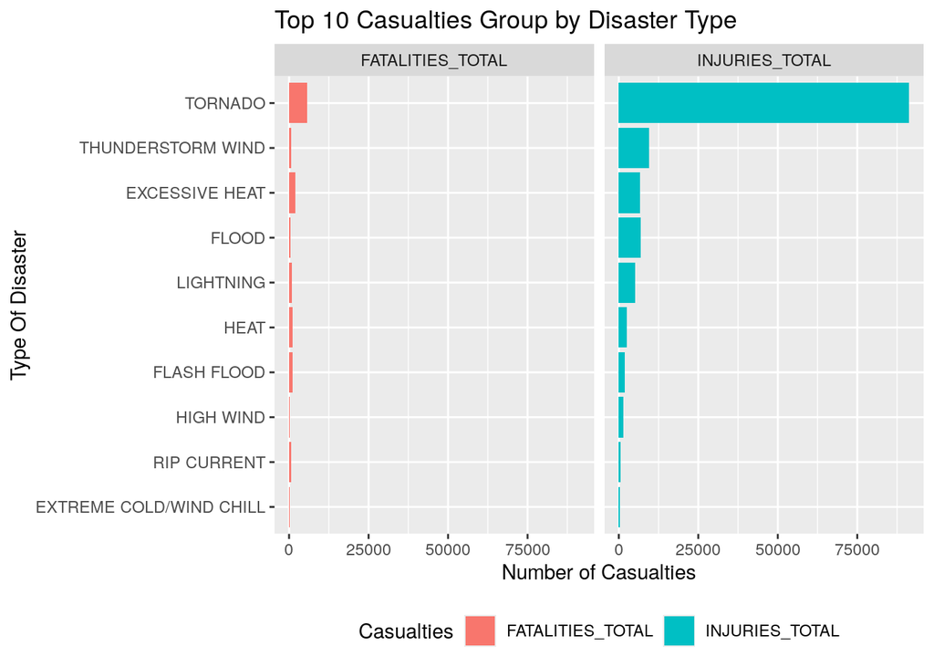

```r
ggplot(meltedPlotDataCasualties, aes(fill=Casualties,x=reorder(EVTYPE, value),y=value))+ geom_bar(position="stack",stat="identity") + ylab("Number of Casualties")+ xlab("Type Of Disaster")+ggtitle("Top 10 Casualties Group by Disaster Type")+ coord_flip()+ facet_grid(. ~ Casualties)+
theme(legend.position="bottom")
```

### Ranked Storm Type with Most Fatalities

```r
rankedCasualties %>%
  kbl() %>%
  kable_styling()
```

| EVTYPE | FATALITIES_TOTAL | INJURIES_TOTAL |
| --- | --- | --- |
| TORNADO | 5658 | 91364 |
| EXCESSIVE HEAT | 2018 | 6730 |
| HEAT | 1118 | 2494 |
| FLASH FLOOD | 1018 | 1785 |
| LIGHTNING | 818 | 5234 |
| THUNDERSTORM WIND | 712 | 9509 |
| RIP CURRENT | 577 | 529 |
| FLOOD | 529 | 6888 |
| EXTREME COLD/WIND CHILL | 306 | 260 |
| HIGH WIND | 293 | 1471 |

### Top 10 Storm Type with Highest Economic Damage

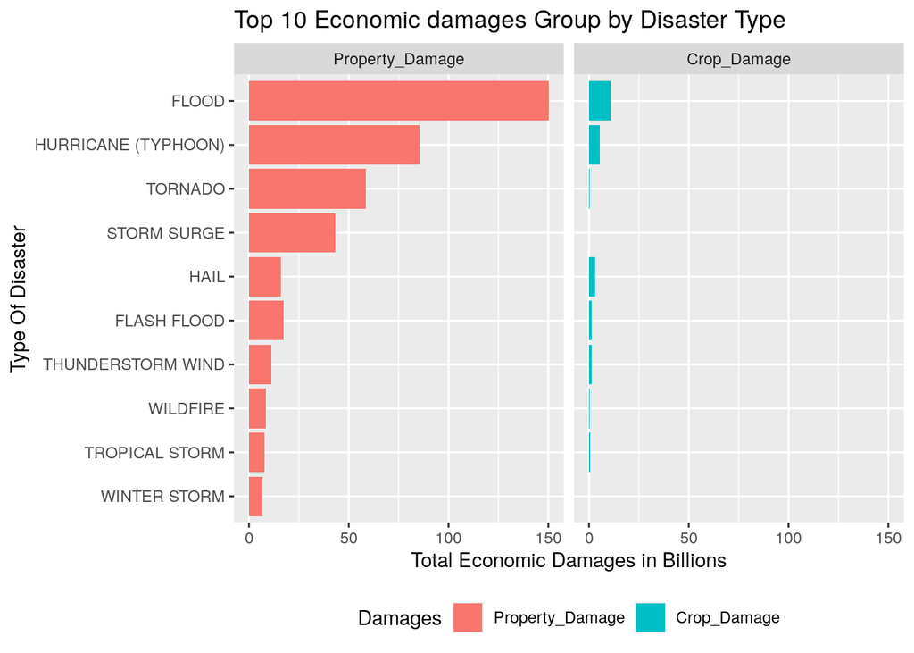

```r
ggplot(meltedPlotDataEcon, aes(fill=Damages,x=reorder(EVTYPE, value),y=value))+ geom_bar(position="stack",stat="identity") + ylab("Total Economic Damages in Billions")+ xlab("Type Of Disaster")+ggtitle("Top 10 Economic damages Group by Disaster Type")+ coord_flip()+
facet_grid(. ~ Damages)+
theme(legend.position="bottom")
```

### Ranked Storm Type with Most Economic Damage

```r
rankedEconomicImpact %>%
  kbl() %>%
  kable_styling()
```

| EVTYPE | Property_Damage | Crop_Damage |
| --- | --- | --- |
| FLOOD | 150.381848 | 10.9459750 |
| HURRICANE (TYPHOON) | 85.356410 | 5.5161178 |
| TORNADO | 58.552152 | 0.4174615 |
| STORM SURGE | 43.323536 | 0.0000050 |
| FLASH FLOOD | 17.414731 | 1.4371631 |
| HAIL | 15.977470 | 3.0260946 |
| THUNDERSTORM WIND | 11.179194 | 1.2716640 |
| WILDFIRE | 8.496628 | 0.4032816 |
| TROPICAL STORM | 7.714391 | 0.6948960 |
| WINTER STORM | 6.748997 | 0.0324440 |

## Conclusion

Based on the results above, policy maker can rank the storm type that caused the most fatalities and perform the same for those storm type that caused the most economic damage. Strategy should be develop to reduce fatalities in Tornado while different strategy should be developed to reduced economic damage caused by flood.